# Extending the 12.4% prevalence grid: naive / field / field-s / IJ two-term on nine cells

- Show All Code
- Hide All Code
- View Source

Campaign p12ext (HR 1.50 at n = 500/1000/1500; the null at n = 1000/1500) beside the four committed tier2 cells; TASK_p12ext_2026-09-09; transplanted from summary_tier2.qmd (globs and labels only)

Author

Larry Leon

Published

September 10, 2026

**Cross-machine note.** The four `tier2` bundles are Mac-produced (`Mac-Studio-3.local`, forestsearch 0.3.5); the five `p12ext` bundles and every `s7c` / `map1c` comparator are `pop-os` (forestsearch 0.3.5). DGM draws are seed-determined and identical across machines, so the pairing below is by **`n_true` (exact) and `truth` (to tolerance)** – never by `identical()` on fitted values.

# 1 Bundles and the pairing identity

```r
library(forestsearch)
library(ggplot2)
library(kableExtra)
`%||%` <- function(a, b) if (is.null(a) || length(a) == 0 || all(is.na(a))) b else a
cells <- list(
  list(key = "h150_n500", label = "HR 1.50, n = 500 [p12ext]", kind = "harm",
       comp = "results/fs_maxeffCons_fb_mr_field_m1_h150_knoise0_n500_map1c_combined_1_2000.rds",
       comp_tag = "map1c",
       e1   = "results/fs_maxeffCons_fb_mr_field_m1_h150_knoise0_n500_p12ext_combined_1_2000.rds"),
  list(key = "h150_n1000", label = "HR 1.50, n = 1000 [p12ext]", kind = "harm",
       comp = NA_character_, comp_tag = "none at this cell",
       e1   = "results/fs_maxeffCons_fb_mr_field_m1_h150_knoise0_n1000_p12ext_combined_1_2000.rds"),
  list(key = "h150_n1500", label = "HR 1.50, n = 1500 [p12ext]", kind = "harm",
       comp = "results/fs_maxeffCons_fb_mr_field_m1_h150_knoise0_n1500_map1c_combined_1_2000.rds",
       comp_tag = "map1c",
       e1   = "results/fs_maxeffCons_fb_mr_field_m1_h150_knoise0_n1500_p12ext_combined_1_2000.rds"),
  list(key = "h175_n500", label = "HR 1.75, n = 500 [tier2]", kind = "harm",
       comp = "results/fs_maxeffCons_fb_mr_field_m1_h175_knoise0_n500_s7c_combined_1_2000.rds",
       comp_tag = "s7c",
       e1   = "results/fs_maxeffCons_fb_mr_field_m1_h175_knoise0_n500_tier2_combined_1_2000.rds"),
  list(key = "h175_n1000", label = "HR 1.75, n = 1000 [tier2]", kind = "harm",
       comp = NA_character_, comp_tag = "none at this cell",
       e1   = "results/fs_maxeffCons_fb_mr_field_m1_h175_knoise0_n1000_tier2_combined_1_2000.rds"),
  list(key = "h175_n1500", label = "HR 1.75, n = 1500 [tier2]", kind = "harm",
       comp = NA_character_, comp_tag = "none exact (map1c h150 n1500 is a different HR)",
       e1   = "results/fs_maxeffCons_fb_mr_field_m1_h175_knoise0_n1500_tier2_combined_1_2000.rds"),
  list(key = "h100_n500", label = "HR 1.00, n = 500 (null) [tier2]", kind = "null",
       comp = "results/fs_maxeffCons_fb_mr_field_m1_h100_knoise0_n500_s7c_combined_1_2000.rds",
       comp_tag = "s7c null",
       e1   = "results/fs_maxeffCons_fb_mr_field_m1_h100_knoise0_n500_tier2_combined_1_2000.rds"),
  list(key = "h100_n1000", label = "HR 1.00, n = 1000 (null) [p12ext]", kind = "null",
       comp = "results/fs_maxeffCons_fb_mr_field_m1_h100_knoise0_n1000_map1c_combined_1_2000.rds",
       comp_tag = "map1c null",
       e1   = "results/fs_maxeffCons_fb_mr_field_m1_h100_knoise0_n1000_p12ext_combined_1_2000.rds"),
  list(key = "h100_n1500", label = "HR 1.00, n = 1500 (null) [p12ext]", kind = "null",
       comp = NA_character_, comp_tag = "none at this cell",
       e1   = "results/fs_maxeffCons_fb_mr_field_m1_h100_knoise0_n1500_p12ext_combined_1_2000.rds"))
timing_cols <- c("fb_secs", "fit_mr_secs", "fld_H_secs", "fld_Hc_secs", "fld_H_uniform_secs")
B <- lapply(cells, function(cl) if (file.exists(cl$e1)) list(e1 = readRDS(cl$e1), comp = if (!is.na(cl$comp) && file.exists(cl$comp)) readRDS(cl$comp) else NULL) else NULL)
names(B) <- vapply(cells, `[[`, "", "key")
labs <- setNames(vapply(cells, `[[`, "", "label"), names(B))
kind <- setNames(vapply(cells, `[[`, "", "kind"), names(B))
comptag <- setNames(vapply(cells, `[[`, "", "comp_tag"), names(B))
pair <- do.call(rbind, lapply(names(B), function(k) { b <- B[[k]]
  if (is.null(b)) return(data.frame(cell = labs[[k]], comparator = comptag[[k]], present = FALSE, n_rows = NA,
    n_detected = NA, n_true_identical = NA, truth_all_equal = NA, truth_max_reldiff = NA))
  rf <- b$e1$results[order(b$e1$results$sim_id), ]
  if (is.null(b$comp)) return(data.frame(cell = labs[[k]], comparator = comptag[[k]], present = TRUE,
    n_rows = nrow(rf), n_detected = sum(rf$detected %in% 1L), n_true_identical = NA,
    truth_all_equal = NA, truth_max_reldiff = NA))
  rc <- b$comp$results[order(b$comp$results$sim_id), ]
  rd <- max(vapply(names(b$comp$truth), function(nm)
    abs(as.numeric(b$e1$truth[[nm]]) - as.numeric(b$comp$truth[[nm]])) / abs(as.numeric(b$comp$truth[[nm]])), 0))
  data.frame(cell = labs[[k]], comparator = comptag[[k]], present = TRUE, n_rows = nrow(rf),
             n_detected = sum(rf$detected %in% 1L),
             n_true_identical = identical(as.integer(rc$n_true), as.integer(rf$n_true)),
             truth_all_equal = isTRUE(all.equal(b$comp$truth, b$e1$truth)), truth_max_reldiff = rd) }))
kbl(pair, booktabs = TRUE, row.names = FALSE, digits = 20, caption = "Bundles read; the pairing by DGM draws: n_true identical() to the committed comparator on every row, and truth equal to tolerance (the residual is the cross-machine BLAS difference; identical() on fitted values is never asserted across machines).") |> kable_styling(font_size = 11)
```

Bundles read; the pairing by DGM draws: n_true identical() to the committed comparator on every row, and truth equal to tolerance (the residual is the cross-machine BLAS difference; identical() on fitted values is never asserted across machines).

| cell | comparator | present | n_rows | n_detected | n_true_identical | truth_all_equal | truth_max_reldiff |
| --- | --- | --- | --- | --- | --- | --- | --- |
| HR 1.50, n = 500 [p12ext] | map1c | TRUE | 2000 | 1822 | TRUE | TRUE | 0.0000e+00 |
| HR 1.50, n = 1000 [p12ext] | none at this cell | TRUE | 2000 | 1948 | NA | NA | NA |
| HR 1.50, n = 1500 [p12ext] | map1c | TRUE | 2000 | 1976 | TRUE | TRUE | 0.0000e+00 |
| HR 1.75, n = 500 [tier2] | s7c | TRUE | 2000 | 1900 | TRUE | TRUE | 6.5451e-16 |
| HR 1.75, n = 1000 [tier2] | none at this cell | TRUE | 2000 | 1990 | NA | NA | NA |
| HR 1.75, n = 1500 [tier2] | none exact (map1c h150 n1500 is a different HR) | TRUE | 2000 | 1998 | NA | NA | NA |
| HR 1.00, n = 500 (null) [tier2] | s7c null | TRUE | 2000 | 1361 | TRUE | TRUE | 3.7971e-16 |
| HR 1.00, n = 1000 (null) [p12ext] | map1c null | TRUE | 2000 | 1319 | TRUE | TRUE | 0.0000e+00 |
| HR 1.00, n = 1500 (null) [p12ext] | none at this cell | TRUE | 2000 | 1248 | NA | NA | NA |

```r
B <- B[!vapply(B, is.null, TRUE)]
```

# 2 Constructions on both blocks: naive / field / field-s / IJ two-term (identical replicates)

```r
# field-s rows come from the same function on a column-substituted copy of the results
# (fld_Hc_* <- fld_Hc_*_s); the harm block has no _s twin (field-s = field there by construction).
subst_s <- function(r) { for (s in c("est2", "up1s", "lo1s", "lo2s", "hi2s", "lo_se", "hi_se", "se", "lam_mean")) r[[paste0("fld_Hc_", s)]] <- r[[paste0("fld_Hc_", s, "_s")]]; r }
err_sd <- function(r, block, est) { d <- r[r$detected %in% 1L, ]
  e <- switch(est, naive = d[[paste0("nv_", block, "_est")]], mr = d[[paste0("mr_", block, "_est")]], fld = d[[paste0("fld_", block, "_est2")]])
  ok <- is.finite(e) & is.finite(d[[paste0("betaHhat_", block)]]); sd(log(e[ok]) - log(d[[paste0("betaHhat_", block)]][ok])) }
cov_block <- function(r, block, side) {
  t1 <- fs_sim_bias_coverage(r, block = block, estimators = c("naive", "mr", "fld"), side = side)
  t1$sd_err <- vapply(as.character(t1$estimator), function(e) err_sd(r, block, e), 0)
  t1$construction <- c(naive = "naive", mr = "IJ two-term", fld = "field")[as.character(t1$estimator)]
  if (block == "Hc") { rs <- subst_s(r); t2 <- fs_sim_bias_coverage(rs, block = "Hc", estimators = "fld", side = side)
    t2$sd_err <- err_sd(rs, "Hc", "fld"); t2$construction <- "field-s"; t1 <- rbind(t1, t2) }
  t1$se_over_sd_err <- t1$se_mean / t1$sd_err
  t1 }
COV <- do.call(rbind, lapply(names(B), function(k) { r <- B[[k]]$e1$results
  rbind(cbind(cell = labs[[k]], block = "Hhat (lower)", cov_block(r, "H", "lower")),
        cbind(cell = labs[[k]], block = "Hhat^c (upper)", cov_block(r, "Hc", "upper"))) }))
COV$construction <- factor(COV$construction, levels = c("naive", "field", "field-s", "IJ two-term"))
COV <- COV[order(match(COV$cell, labs), COV$block, COV$construction), ]
kbl(COV[, c("cell", "block", "construction", "n", "bias_log", "sd_emp", "sd_err", "se_mean", "b", "r", "se_over_sd_err", "cov1", "cov1_wilson_lo", "cov1_wilson_hi", "cov2", "cov1_ref")],
    digits = 3, booktabs = TRUE, row.names = FALSE,
    caption = "Per cell: bias (log), marginal SD (sd_emp), error-scale SD (sd_err = SD of log est - log target), mean SE, b = bias / marginal SD, r = mean SE / marginal SD, SE / error SD; cov1 = one-sided 95% coverage of beta(Hhat) by the lower bound / of beta(Hhat^c) by the upper bound with Wilson limits; cov2 = two-sided; cov1_ref = Gaussian reference. The harm block has no field-s row: it is untouched by construction.") |>
  kable_styling(font_size = 10)
```

Per cell: bias (log), marginal SD (sd_emp), error-scale SD (sd_err = SD of log est - log target), mean SE, b = bias / marginal SD, r = mean SE / marginal SD, SE / error SD; cov1 = one-sided 95% coverage of beta(Hhat) by the lower bound / of beta(Hhat^c) by the upper bound with Wilson limits; cov2 = two-sided; cov1_ref = Gaussian reference. The harm block has no field-s row: it is untouched by construction.

| cell | block | construction | n | bias_log | sd_emp | sd_err | se_mean | b | r | se_over_sd_err | cov1 | cov1_wilson_lo | cov1_wilson_hi | cov2 | cov1_ref |
| --- | --- | --- | --- | --- | --- | --- | --- | --- | --- | --- | --- | --- | --- | --- | --- |
| HR 1.50, n = 500 [p12ext] | Hhat (lower) | naive | 1822 | 0.580 | 0.199 | 0.321 | 0.315 | 2.922 | 1.587 | 0.980 | 0.417 | 0.394 | 0.439 | 0.529 | 0.378 |
| HR 1.50, n = 500 [p12ext] | Hhat (lower) | field | 1822 | -0.021 | 0.316 | 0.373 | 0.359 | -0.066 | 1.137 | 0.964 | 0.965 | 0.956 | 0.973 | 0.919 | 0.974 |
| HR 1.50, n = 500 [p12ext] | Hhat (lower) | IJ two-term | 1822 | 0.059 | 0.276 | 0.354 | 0.395 | 0.213 | 1.431 | 1.115 | 0.978 | 0.970 | 0.984 | 0.977 | 0.984 |
| HR 1.50, n = 500 [p12ext] | Hhat^c (upper) | naive | 1822 | -0.081 | 0.136 | 0.135 | 0.139 | -0.592 | 1.018 | 1.026 | 0.864 | 0.848 | 0.879 | 0.915 | 0.861 |
| HR 1.50, n = 500 [p12ext] | Hhat^c (upper) | field | 1822 | -0.005 | 0.145 | 0.142 | 0.136 | -0.036 | 0.938 | 0.954 | 0.936 | 0.924 | 0.947 | 0.935 | 0.934 |
| HR 1.50, n = 500 [p12ext] | Hhat^c (upper) | field-s | 1822 | -0.005 | 0.145 | 0.142 | 0.138 | -0.037 | 0.952 | 0.968 | 0.937 | 0.925 | 0.948 | 0.939 | 0.937 |
| HR 1.50, n = 500 [p12ext] | Hhat^c (upper) | IJ two-term | 1822 | -0.015 | 0.141 | 0.139 | 0.256 | -0.105 | 1.813 | 1.836 | 0.997 | 0.993 | 0.998 | 1.000 | 0.998 |
| HR 1.50, n = 1000 [p12ext] | Hhat (lower) | naive | 1948 | 0.310 | 0.184 | 0.295 | 0.235 | 1.689 | 1.280 | 0.798 | 0.642 | 0.620 | 0.663 | 0.737 | 0.661 |
| HR 1.50, n = 1000 [p12ext] | Hhat (lower) | field | 1948 | -0.065 | 0.298 | 0.334 | 0.275 | -0.220 | 0.922 | 0.823 | 0.941 | 0.930 | 0.951 | 0.856 | 0.959 |
| HR 1.50, n = 1000 [p12ext] | Hhat (lower) | IJ two-term | 1948 | -0.032 | 0.260 | 0.320 | 0.298 | -0.124 | 1.146 | 0.931 | 0.971 | 0.963 | 0.978 | 0.932 | 0.978 |
| HR 1.50, n = 1000 [p12ext] | Hhat^c (upper) | naive | 1948 | -0.035 | 0.097 | 0.094 | 0.097 | -0.364 | 0.995 | 1.030 | 0.912 | 0.899 | 0.924 | 0.947 | 0.898 |
| HR 1.50, n = 1000 [p12ext] | Hhat^c (upper) | field | 1948 | 0.007 | 0.104 | 0.098 | 0.096 | 0.066 | 0.924 | 0.974 | 0.951 | 0.941 | 0.960 | 0.941 | 0.944 |
| HR 1.50, n = 1000 [p12ext] | Hhat^c (upper) | field-s | 1948 | 0.007 | 0.104 | 0.098 | 0.097 | 0.065 | 0.933 | 0.984 | 0.953 | 0.943 | 0.962 | 0.945 | 0.945 |
| HR 1.50, n = 1000 [p12ext] | Hhat^c (upper) | IJ two-term | 1948 | 0.003 | 0.101 | 0.097 | 0.182 | 0.031 | 1.802 | 1.883 | 0.999 | 0.997 | 1.000 | 0.999 | 0.999 |
| HR 1.50, n = 1500 [p12ext] | Hhat (lower) | naive | 1976 | 0.145 | 0.158 | 0.224 | 0.183 | 0.915 | 1.159 | 0.820 | 0.808 | 0.790 | 0.825 | 0.866 | 0.839 |
| HR 1.50, n = 1500 [p12ext] | Hhat (lower) | field | 1976 | -0.086 | 0.259 | 0.273 | 0.230 | -0.334 | 0.890 | 0.841 | 0.956 | 0.947 | 0.965 | 0.848 | 0.964 |
| HR 1.50, n = 1500 [p12ext] | Hhat (lower) | IJ two-term | 1976 | -0.084 | 0.227 | 0.257 | 0.246 | -0.371 | 1.082 | 0.954 | 0.981 | 0.974 | 0.986 | 0.901 | 0.984 |
| HR 1.50, n = 1500 [p12ext] | Hhat^c (upper) | naive | 1976 | -0.020 | 0.079 | 0.077 | 0.079 | -0.249 | 1.011 | 1.036 | 0.923 | 0.910 | 0.934 | 0.953 | 0.921 |
| HR 1.50, n = 1500 [p12ext] | Hhat^c (upper) | field | 1976 | 0.007 | 0.084 | 0.081 | 0.079 | 0.081 | 0.941 | 0.980 | 0.956 | 0.947 | 0.965 | 0.946 | 0.948 |
| HR 1.50, n = 1500 [p12ext] | Hhat^c (upper) | field-s | 1976 | 0.007 | 0.084 | 0.081 | 0.080 | 0.079 | 0.951 | 0.990 | 0.959 | 0.949 | 0.966 | 0.952 | 0.950 |
| HR 1.50, n = 1500 [p12ext] | Hhat^c (upper) | IJ two-term | 1976 | 0.007 | 0.082 | 0.080 | 0.151 | 0.081 | 1.837 | 1.897 | 0.999 | 0.996 | 1.000 | 0.999 | 0.999 |
| HR 1.75, n = 500 [tier2] | Hhat (lower) | naive | 1900 | 0.481 | 0.222 | 0.349 | 0.310 | 2.165 | 1.395 | 0.888 | 0.539 | 0.516 | 0.561 | 0.645 | 0.551 |
| HR 1.75, n = 500 [tier2] | Hhat (lower) | field | 1900 | -0.075 | 0.358 | 0.399 | 0.363 | -0.209 | 1.014 | 0.910 | 0.966 | 0.957 | 0.974 | 0.887 | 0.970 |
| HR 1.75, n = 500 [tier2] | Hhat (lower) | IJ two-term | 1900 | -0.010 | 0.312 | 0.380 | 0.393 | -0.032 | 1.260 | 1.034 | 0.983 | 0.976 | 0.988 | 0.961 | 0.982 |
| HR 1.75, n = 500 [tier2] | Hhat^c (upper) | naive | 1900 | -0.070 | 0.138 | 0.137 | 0.139 | -0.511 | 1.007 | 1.011 | 0.876 | 0.861 | 0.890 | 0.921 | 0.874 |
| HR 1.75, n = 500 [tier2] | Hhat^c (upper) | field | 1900 | -0.001 | 0.147 | 0.144 | 0.136 | -0.004 | 0.927 | 0.948 | 0.936 | 0.924 | 0.946 | 0.934 | 0.936 |
| HR 1.75, n = 500 [tier2] | Hhat^c (upper) | field-s | 1900 | -0.001 | 0.147 | 0.144 | 0.138 | -0.005 | 0.942 | 0.962 | 0.941 | 0.929 | 0.950 | 0.938 | 0.939 |
| HR 1.75, n = 500 [tier2] | Hhat^c (upper) | IJ two-term | 1900 | -0.008 | 0.143 | 0.141 | 0.257 | -0.058 | 1.800 | 1.825 | 0.999 | 0.996 | 1.000 | 1.000 | 0.998 |
| HR 1.75, n = 1000 [tier2] | Hhat (lower) | naive | 1990 | 0.213 | 0.202 | 0.291 | 0.228 | 1.056 | 1.134 | 0.786 | 0.757 | 0.737 | 0.775 | 0.824 | 0.791 |
| HR 1.75, n = 1000 [tier2] | Hhat (lower) | field | 1990 | -0.091 | 0.323 | 0.339 | 0.280 | -0.282 | 0.867 | 0.826 | 0.944 | 0.933 | 0.953 | 0.850 | 0.956 |
| HR 1.75, n = 1000 [tier2] | Hhat (lower) | IJ two-term | 1990 | -0.081 | 0.285 | 0.323 | 0.302 | -0.283 | 1.059 | 0.933 | 0.975 | 0.968 | 0.981 | 0.917 | 0.979 |
| HR 1.75, n = 1000 [tier2] | Hhat^c (upper) | naive | 1990 | -0.026 | 0.099 | 0.096 | 0.097 | -0.258 | 0.979 | 1.006 | 0.926 | 0.914 | 0.937 | 0.949 | 0.912 |
| HR 1.75, n = 1000 [tier2] | Hhat^c (upper) | field | 1990 | 0.008 | 0.106 | 0.101 | 0.096 | 0.080 | 0.913 | 0.958 | 0.955 | 0.945 | 0.963 | 0.936 | 0.943 |
| HR 1.75, n = 1000 [tier2] | Hhat^c (upper) | field-s | 1990 | 0.008 | 0.106 | 0.101 | 0.098 | 0.078 | 0.922 | 0.968 | 0.956 | 0.946 | 0.964 | 0.940 | 0.945 |
| HR 1.75, n = 1000 [tier2] | Hhat^c (upper) | IJ two-term | 1990 | 0.007 | 0.103 | 0.099 | 0.184 | 0.071 | 1.784 | 1.855 | 0.998 | 0.996 | 0.999 | 0.999 | 0.999 |
| HR 1.75, n = 1500 [tier2] | Hhat (lower) | naive | 1998 | 0.083 | 0.170 | 0.208 | 0.179 | 0.488 | 1.051 | 0.860 | 0.881 | 0.866 | 0.894 | 0.910 | 0.893 |
| HR 1.75, n = 1500 [tier2] | Hhat (lower) | field | 1998 | -0.075 | 0.262 | 0.261 | 0.231 | -0.286 | 0.882 | 0.887 | 0.960 | 0.950 | 0.968 | 0.878 | 0.959 |
| HR 1.75, n = 1500 [tier2] | Hhat (lower) | IJ two-term | 1998 | -0.093 | 0.236 | 0.247 | 0.258 | -0.393 | 1.090 | 1.045 | 0.989 | 0.983 | 0.993 | 0.913 | 0.986 |
| HR 1.75, n = 1500 [tier2] | Hhat^c (upper) | naive | 1998 | -0.013 | 0.079 | 0.078 | 0.080 | -0.162 | 1.010 | 1.027 | 0.935 | 0.923 | 0.945 | 0.957 | 0.933 |
| HR 1.75, n = 1500 [tier2] | Hhat^c (upper) | field | 1998 | 0.005 | 0.084 | 0.081 | 0.080 | 0.061 | 0.955 | 0.988 | 0.959 | 0.950 | 0.967 | 0.950 | 0.949 |
| HR 1.75, n = 1500 [tier2] | Hhat^c (upper) | field-s | 1998 | 0.005 | 0.084 | 0.081 | 0.081 | 0.059 | 0.964 | 0.998 | 0.960 | 0.951 | 0.968 | 0.951 | 0.950 |
| HR 1.75, n = 1500 [tier2] | Hhat^c (upper) | IJ two-term | 1998 | 0.007 | 0.082 | 0.080 | 0.153 | 0.089 | 1.860 | 1.910 | 0.999 | 0.996 | 1.000 | 0.999 | 0.999 |
| HR 1.00, n = 500 (null) [tier2] | Hhat (lower) | naive | 1361 | 0.813 | 0.163 | 0.211 | 0.324 | 4.997 | 1.989 | 1.538 | 0.051 | 0.040 | 0.064 | 0.157 | 0.042 |
| HR 1.00, n = 500 (null) [tier2] | Hhat (lower) | field | 1361 | 0.140 | 0.253 | 0.279 | 0.357 | 0.556 | 1.410 | 1.279 | 0.963 | 0.951 | 0.971 | 0.988 | 0.961 |
| HR 1.00, n = 500 (null) [tier2] | Hhat (lower) | IJ two-term | 1361 | 0.244 | 0.222 | 0.255 | 0.399 | 1.098 | 1.794 | 1.564 | 0.966 | 0.955 | 0.975 | 0.986 | 0.968 |
| HR 1.00, n = 500 (null) [tier2] | Hhat^c (upper) | naive | 1361 | -0.090 | 0.131 | 0.129 | 0.139 | -0.688 | 1.060 | 1.078 | 0.859 | 0.839 | 0.876 | 0.911 | 0.855 |
| HR 1.00, n = 500 (null) [tier2] | Hhat^c (upper) | field | 1361 | -0.010 | 0.141 | 0.139 | 0.136 | -0.069 | 0.966 | 0.980 | 0.930 | 0.915 | 0.943 | 0.950 | 0.936 |
| HR 1.00, n = 500 (null) [tier2] | Hhat^c (upper) | field-s | 1361 | -0.010 | 0.141 | 0.139 | 0.138 | -0.069 | 0.983 | 0.998 | 0.940 | 0.926 | 0.951 | 0.952 | 0.939 |
| HR 1.00, n = 500 (null) [tier2] | Hhat^c (upper) | IJ two-term | 1361 | -0.021 | 0.137 | 0.135 | 0.255 | -0.156 | 1.854 | 1.882 | 0.997 | 0.992 | 0.999 | 1.000 | 0.998 |
| HR 1.00, n = 1000 (null) [p12ext] | Hhat (lower) | naive | 1319 | 0.604 | 0.142 | 0.225 | 0.252 | 4.265 | 1.778 | 1.119 | 0.161 | 0.142 | 0.182 | 0.269 | 0.090 |
| HR 1.00, n = 1000 (null) [p12ext] | Hhat (lower) | field | 1319 | 0.106 | 0.216 | 0.263 | 0.264 | 0.489 | 1.225 | 1.004 | 0.920 | 0.905 | 0.934 | 0.958 | 0.937 |
| HR 1.00, n = 1000 (null) [p12ext] | Hhat (lower) | IJ two-term | 1319 | 0.181 | 0.191 | 0.251 | 0.298 | 0.944 | 1.560 | 1.189 | 0.936 | 0.922 | 0.948 | 0.980 | 0.948 |
| HR 1.00, n = 1000 (null) [p12ext] | Hhat^c (upper) | naive | 1319 | -0.044 | 0.092 | 0.090 | 0.097 | -0.479 | 1.050 | 1.077 | 0.908 | 0.891 | 0.922 | 0.943 | 0.894 |
| HR 1.00, n = 1000 (null) [p12ext] | Hhat^c (upper) | field | 1319 | 0.008 | 0.099 | 0.097 | 0.095 | 0.077 | 0.958 | 0.983 | 0.953 | 0.940 | 0.963 | 0.945 | 0.951 |
| HR 1.00, n = 1000 (null) [p12ext] | Hhat^c (upper) | field-s | 1319 | 0.007 | 0.099 | 0.097 | 0.096 | 0.075 | 0.966 | 0.991 | 0.956 | 0.944 | 0.966 | 0.950 | 0.952 |
| HR 1.00, n = 1000 (null) [p12ext] | Hhat^c (upper) | IJ two-term | 1319 | 0.000 | 0.097 | 0.094 | 0.179 | 0.004 | 1.854 | 1.901 | 0.998 | 0.993 | 0.999 | 1.000 | 0.999 |
| HR 1.00, n = 1500 (null) [p12ext] | Hhat (lower) | naive | 1248 | 0.435 | 0.111 | 0.194 | 0.199 | 3.931 | 1.799 | 1.025 | 0.288 | 0.264 | 0.314 | 0.420 | 0.166 |
| HR 1.00, n = 1500 (null) [p12ext] | Hhat (lower) | field | 1248 | 0.047 | 0.184 | 0.227 | 0.217 | 0.257 | 1.180 | 0.957 | 0.930 | 0.915 | 0.943 | 0.954 | 0.954 |
| HR 1.00, n = 1500 (null) [p12ext] | Hhat (lower) | IJ two-term | 1248 | 0.102 | 0.159 | 0.216 | 0.233 | 0.640 | 1.466 | 1.078 | 0.948 | 0.934 | 0.959 | 0.982 | 0.962 |
| HR 1.00, n = 1500 (null) [p12ext] | Hhat^c (upper) | naive | 1248 | -0.033 | 0.075 | 0.072 | 0.079 | -0.447 | 1.063 | 1.098 | 0.911 | 0.894 | 0.926 | 0.945 | 0.903 |
| HR 1.00, n = 1500 (null) [p12ext] | Hhat^c (upper) | field | 1248 | 0.005 | 0.081 | 0.078 | 0.078 | 0.064 | 0.963 | 0.995 | 0.949 | 0.935 | 0.960 | 0.950 | 0.950 |
| HR 1.00, n = 1500 (null) [p12ext] | Hhat^c (upper) | field-s | 1248 | 0.005 | 0.081 | 0.078 | 0.079 | 0.062 | 0.972 | 1.004 | 0.950 | 0.936 | 0.960 | 0.952 | 0.952 |
| HR 1.00, n = 1500 (null) [p12ext] | Hhat^c (upper) | IJ two-term | 1248 | 0.001 | 0.079 | 0.076 | 0.147 | 0.008 | 1.863 | 1.921 | 0.999 | 0.995 | 1.000 | 1.000 | 0.999 |

```r
ACR <- do.call(rbind, lapply(split(COV, list(COV$block, COV$construction), drop = TRUE), function(d)
  data.frame(block = d$block[1], construction = d$construction[1], cells = nrow(d), cov1_min = min(d$cov1), cov1_mean = mean(d$cov1), cov1_max = max(d$cov1),
             cov2_mean = mean(d$cov2), b_mean = mean(d$b), r_mean = mean(d$r), se_over_sd_err_mean = mean(d$se_over_sd_err))))
ACR <- ACR[order(ACR$block, ACR$construction), ]
kbl(ACR, digits = 3, booktabs = TRUE, row.names = FALSE, caption = "Across cells: range and mean of the one-sided coverage, mean two-sided coverage, mean b and r.") |> kable_styling(font_size = 10)
```

Across cells: range and mean of the one-sided coverage, mean two-sided coverage, mean b and r.

| block | construction | cells | cov1_min | cov1_mean | cov1_max | cov2_mean | b_mean | r_mean | se_over_sd_err_mean |
| --- | --- | --- | --- | --- | --- | --- | --- | --- | --- |
| Hhat (lower) | naive | 9 | 0.051 | 0.505 | 0.881 | 0.595 | 2.492 | 1.463 | 0.979 |
| Hhat (lower) | field | 9 | 0.920 | 0.950 | 0.966 | 0.904 | -0.011 | 1.059 | 0.943 |
| Hhat (lower) | IJ two-term | 9 | 0.936 | 0.970 | 0.989 | 0.950 | 0.188 | 1.321 | 1.094 |
| Hhat^c (upper) | naive | 9 | 0.859 | 0.902 | 0.935 | 0.938 | -0.417 | 1.021 | 1.043 |
| Hhat^c (upper) | field | 9 | 0.930 | 0.947 | 0.959 | 0.943 | 0.036 | 0.943 | 0.973 |
| Hhat^c (upper) | field-s | 9 | 0.937 | 0.950 | 0.960 | 0.947 | 0.034 | 0.954 | 0.985 |
| Hhat^c (upper) | IJ two-term | 9 | 0.997 | 0.998 | 0.999 | 1.000 | -0.004 | 1.830 | 1.879 |

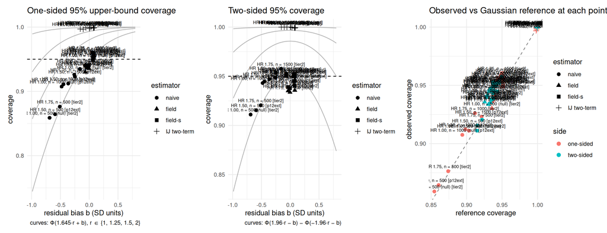

```r
tabC <- COV[COV$block == "Hhat^c (upper)", ]; tabC$estimator <- tabC$construction
fs_plot_bias_coverage(tabC, curves = c(1, 1.25, 1.5, 2), side = "upper")
```

# 3 Finding 1 - Complement upper coverage: field vs field-s (Wilson), per cell

```r
wil <- function(x, n, z = qnorm(.975)) { c <- (x + z^2/(2*n))/(1+z^2/n); h <- z*sqrt(x*(1-x)/n + z^2/(4*n^2))/(1+z^2/n); c(c - h, c + h) }
F1 <- do.call(rbind, lapply(names(B), function(k) { r <- B[[k]]$e1$results; d <- r[r$detected %in% 1L & is.finite(r$betaHhat_Hc) & is.finite(r$fld_Hc_up1s_s), ]
  cf <- mean(d$betaHhat_Hc <= d$fld_Hc_up1s); cs <- mean(d$betaHhat_Hc <= d$fld_Hc_up1s_s); ci <- mean(d$betaHhat_Hc <= exp(log(d$mr_Hc_est) + qnorm(.95) * d$mr_Hc_se_ij))
  wf <- wil(cf, nrow(d)); ws <- wil(cs, nrow(d)); wi <- wil(ci, nrow(d))
  data.frame(cell = labs[[k]], kind = kind[[k]], n = nrow(d), field = cf, field_lo = wf[1], field_hi = wf[2], field_s = cs, field_s_lo = ws[1], field_s_hi = ws[2],
             ij = ci, ij_lo = wi[1], ij_hi = wi[2], field_s_minus_field = cs - cf, share_flipped_to_cover = mean(d$betaHhat_Hc > d$fld_Hc_up1s & d$betaHhat_Hc <= d$fld_Hc_up1s_s),
             share_flipped_to_miss = mean(d$betaHhat_Hc <= d$fld_Hc_up1s & d$betaHhat_Hc > d$fld_Hc_up1s_s), mean_rho_c = mean(d$fld_Hc_scale_ratio), lamSD_over_nSE = sqrt(mean(d$fld_Hc_se^2)) / sqrt(mean(d$nv_Hc_se^2)),
             lamSDs_over_nSE = sqrt(mean(d$fld_Hc_se_s^2)) / sqrt(mean(d$nv_Hc_se^2)), field_s_ge_093 = ws[1] >= 0.93, field_s_point_ge_093 = cs >= 0.93) }))
kbl(F1, digits = 3, booktabs = TRUE, row.names = FALSE, caption = "One-sided 95% upper coverage of beta(Hhat^c): field, field-s, IJ two-term with Wilson limits; the replicates that flip; mean rho^c and the lambda-SD / naive SE ratios (unscaled and studentized). field_s_ge_093: the Wilson lower limit reaches the tier2 bar 0.93 (reference line only; no criterion is pre-registered for p12ext); field_s_point_ge_093: the point estimate does.") |> kable_styling(font_size = 10)
```

One-sided 95% upper coverage of beta(Hhat^c): field, field-s, IJ two-term with Wilson limits; the replicates that flip; mean rho^c and the lambda-SD / naive SE ratios (unscaled and studentized). field_s_ge_093: the Wilson lower limit reaches the tier2 bar 0.93 (reference line only; no criterion is pre-registered for p12ext); field_s_point_ge_093: the point estimate does.

| cell | kind | n | field | field_lo | field_hi | field_s | field_s_lo | field_s_hi | ij | ij_lo | ij_hi | field_s_minus_field | share_flipped_to_cover | share_flipped_to_miss | mean_rho_c | lamSD_over_nSE | lamSDs_over_nSE | field_s_ge_093 | field_s_point_ge_093 |
| --- | --- | --- | --- | --- | --- | --- | --- | --- | --- | --- | --- | --- | --- | --- | --- | --- | --- | --- | --- |
| HR 1.50, n = 500 [p12ext] | harm | 1822 | 0.936 | 0.924 | 0.947 | 0.937 | 0.925 | 0.948 | 0.997 | 0.993 | 0.998 | 0.001 | 0.003 | 0.002 | 1.016 | 0.980 | 0.995 | FALSE | TRUE |
| HR 1.50, n = 1000 [p12ext] | harm | 1948 | 0.951 | 0.941 | 0.960 | 0.953 | 0.943 | 0.962 | 0.999 | 0.997 | 1.000 | 0.002 | 0.002 | 0.000 | 1.010 | 0.990 | 1.000 | TRUE | TRUE |
| HR 1.50, n = 1500 [p12ext] | harm | 1976 | 0.956 | 0.947 | 0.965 | 0.959 | 0.949 | 0.966 | 0.999 | 0.996 | 1.000 | 0.002 | 0.002 | 0.000 | 1.010 | 0.997 | 1.008 | TRUE | TRUE |
| HR 1.75, n = 500 [tier2] | harm | 1900 | 0.936 | 0.924 | 0.946 | 0.941 | 0.929 | 0.950 | 0.999 | 0.996 | 1.000 | 0.005 | 0.005 | 0.000 | 1.017 | 0.982 | 0.998 | FALSE | TRUE |
| HR 1.75, n = 1000 [tier2] | harm | 1990 | 0.955 | 0.945 | 0.963 | 0.956 | 0.946 | 0.964 | 0.998 | 0.996 | 0.999 | 0.002 | 0.002 | 0.001 | 1.010 | 0.995 | 1.006 | TRUE | TRUE |
| HR 1.75, n = 1500 [tier2] | harm | 1998 | 0.959 | 0.950 | 0.967 | 0.960 | 0.951 | 0.968 | 0.999 | 0.996 | 1.000 | 0.001 | 0.001 | 0.000 | 1.010 | 1.005 | 1.015 | TRUE | TRUE |
| HR 1.00, n = 500 (null) [tier2] | null | 1361 | 0.930 | 0.915 | 0.943 | 0.940 | 0.926 | 0.951 | 0.997 | 0.992 | 0.999 | 0.010 | 0.011 | 0.001 | 1.020 | 0.975 | 0.993 | FALSE | TRUE |
| HR 1.00, n = 1000 (null) [p12ext] | null | 1319 | 0.953 | 0.940 | 0.963 | 0.956 | 0.944 | 0.966 | 0.998 | 0.993 | 0.999 | 0.003 | 0.004 | 0.001 | 1.010 | 0.982 | 0.991 | TRUE | TRUE |
| HR 1.00, n = 1500 (null) [p12ext] | null | 1248 | 0.949 | 0.935 | 0.960 | 0.950 | 0.936 | 0.960 | 0.999 | 0.995 | 1.000 | 0.001 | 0.001 | 0.000 | 1.010 | 0.984 | 0.993 | TRUE | TRUE |

# 4 Finding 2 - The shape test: complement upper coverage by |Hhat|/|H| tertile and by p-hat tertile

```r
tert <- function(v) { br <- quantile(v, c(0, 1/3, 2/3, 1), names = FALSE); cut(v, breaks = unique(br), include.lowest = TRUE, labels = FALSE) }
F2 <- do.call(rbind, lapply(names(B), function(k) { r <- B[[k]]$e1$results; d <- r[r$detected %in% 1L & is.finite(r$betaHhat_Hc) & is.finite(r$fld_Hc_up1s_s), ]
  do.call(rbind, lapply(c("|Hhat|/|H|", "p-hat"), function(what) { v <- if (what == "p-hat") d$p_hat_H else d$n_harm / d$n_true; g <- tert(v)
    do.call(rbind, lapply(sort(unique(g)), function(t) { dk <- d[g == t, ]; cf <- mean(dk$betaHhat_Hc <= dk$fld_Hc_up1s); cs <- mean(dk$betaHhat_Hc <= dk$fld_Hc_up1s_s)
      wf <- wil(cf, nrow(dk)); ws <- wil(cs, nrow(dk))
      data.frame(cell = labs[[k]], stratum = sprintf("%s T%d [%.2f, %.2f]", what, t, min(v[g == t]), max(v[g == t])), n = nrow(dk), mean_rho_c = mean(dk$fld_Hc_scale_ratio),
                 fld_over_nv = mean(dk$fld_Hc_se / dk$nv_Hc_se), flds_over_nv = mean(dk$fld_Hc_se_s / dk$nv_Hc_se),
                 field = cf, field_lo = wf[1], field_hi = wf[2], field_s = cs, field_s_lo = ws[1], field_s_hi = ws[2]) })) })) }))
kbl(F2, digits = 3, booktabs = TRUE, row.names = FALSE, caption = "Within each cell, by |Hhat|/|H| tertile and by p-hat(Hhat) tertile: mean rho^c, the per-replicate SE ratios, and the field / field-s upper coverage of beta(Hhat^c) with Wilson limits.") |> kable_styling(font_size = 9)
```

Within each cell, by |Hhat|/|H| tertile and by p-hat(Hhat) tertile: mean rho^c, the per-replicate SE ratios, and the field / field-s upper coverage of beta(Hhat^c) with Wilson limits.

| cell | stratum | n | mean_rho_c | fld_over_nv | flds_over_nv | field | field_lo | field_hi | field_s | field_s_lo | field_s_hi |
| --- | --- | --- | --- | --- | --- | --- | --- | --- | --- | --- | --- |
| HR 1.50, n = 500 [p12ext] | \|Hhat\|/\|H\| T1 [0.66, 1.05] | 608 | 1.010 | 0.986 | 0.996 | 0.939 | 0.917 | 0.956 | 0.938 | 0.915 | 0.954 |
| HR 1.50, n = 500 [p12ext] | \|Hhat\|/\|H\| T2 [1.05, 1.23] | 608 | 1.013 | 0.983 | 0.994 | 0.936 | 0.914 | 0.953 | 0.936 | 0.914 | 0.953 |
| HR 1.50, n = 500 [p12ext] | \|Hhat\|/\|H\| T3 [1.23, 3.66] | 606 | 1.026 | 0.972 | 0.995 | 0.934 | 0.911 | 0.951 | 0.939 | 0.917 | 0.955 |
| HR 1.50, n = 500 [p12ext] | p-hat T1 [0.00, 0.12] | 609 | 1.029 | 0.969 | 0.995 | 0.946 | 0.925 | 0.961 | 0.951 | 0.931 | 0.965 |
| HR 1.50, n = 500 [p12ext] | p-hat T2 [0.12, 0.23] | 606 | 1.014 | 0.977 | 0.990 | 0.959 | 0.940 | 0.972 | 0.959 | 0.940 | 0.972 |
| HR 1.50, n = 500 [p12ext] | p-hat T3 [0.23, 0.94] | 607 | 1.006 | 0.995 | 1.000 | 0.904 | 0.878 | 0.925 | 0.903 | 0.877 | 0.924 |
| HR 1.50, n = 1000 [p12ext] | \|Hhat\|/\|H\| T1 [0.67, 0.92] | 651 | 1.000 | 1.000 | 0.999 | 0.960 | 0.942 | 0.973 | 0.960 | 0.942 | 0.973 |
| HR 1.50, n = 1000 [p12ext] | \|Hhat\|/\|H\| T2 [0.92, 1.04] | 648 | 1.012 | 0.990 | 1.001 | 0.949 | 0.929 | 0.964 | 0.951 | 0.931 | 0.965 |
| HR 1.50, n = 1000 [p12ext] | \|Hhat\|/\|H\| T3 [1.04, 2.40] | 649 | 1.019 | 0.981 | 0.999 | 0.945 | 0.924 | 0.960 | 0.949 | 0.929 | 0.964 |
| HR 1.50, n = 1000 [p12ext] | p-hat T1 [0.00, 0.20] | 652 | 1.019 | 0.975 | 0.993 | 0.962 | 0.944 | 0.974 | 0.965 | 0.948 | 0.976 |
| HR 1.50, n = 1000 [p12ext] | p-hat T2 [0.20, 0.34] | 647 | 1.007 | 0.990 | 0.997 | 0.961 | 0.944 | 0.974 | 0.963 | 0.945 | 0.975 |
| HR 1.50, n = 1000 [p12ext] | p-hat T3 [0.34, 0.93] | 649 | 1.004 | 1.006 | 1.010 | 0.931 | 0.908 | 0.948 | 0.932 | 0.910 | 0.949 |
| HR 1.50, n = 1500 [p12ext] | \|Hhat\|/\|H\| T1 [0.70, 0.97] | 659 | 0.998 | 1.008 | 1.006 | 0.942 | 0.922 | 0.958 | 0.945 | 0.925 | 0.960 |
| HR 1.50, n = 1500 [p12ext] | \|Hhat\|/\|H\| T2 [0.97, 1.05] | 659 | 1.015 | 0.993 | 1.009 | 0.974 | 0.959 | 0.984 | 0.974 | 0.959 | 0.984 |
| HR 1.50, n = 1500 [p12ext] | \|Hhat\|/\|H\| T3 [1.05, 3.25] | 658 | 1.018 | 0.990 | 1.009 | 0.953 | 0.934 | 0.967 | 0.956 | 0.937 | 0.969 |
| HR 1.50, n = 1500 [p12ext] | p-hat T1 [0.00, 0.28] | 660 | 1.017 | 0.982 | 0.998 | 0.970 | 0.954 | 0.980 | 0.973 | 0.957 | 0.983 |
| HR 1.50, n = 1500 [p12ext] | p-hat T2 [0.28, 0.46] | 657 | 1.008 | 0.998 | 1.006 | 0.960 | 0.943 | 0.973 | 0.963 | 0.946 | 0.975 |
| HR 1.50, n = 1500 [p12ext] | p-hat T3 [0.46, 0.99] | 659 | 1.006 | 1.012 | 1.019 | 0.939 | 0.918 | 0.955 | 0.939 | 0.918 | 0.955 |
| HR 1.75, n = 500 [tier2] | \|Hhat\|/\|H\| T1 [0.66, 1.04] | 635 | 1.012 | 0.989 | 1.000 | 0.945 | 0.924 | 0.960 | 0.946 | 0.926 | 0.961 |
| HR 1.75, n = 500 [tier2] | \|Hhat\|/\|H\| T2 [1.04, 1.20] | 633 | 1.014 | 0.984 | 0.997 | 0.926 | 0.903 | 0.944 | 0.929 | 0.906 | 0.946 |
| HR 1.75, n = 500 [tier2] | \|Hhat\|/\|H\| T3 [1.21, 3.66] | 632 | 1.024 | 0.975 | 0.997 | 0.937 | 0.915 | 0.953 | 0.946 | 0.926 | 0.961 |
| HR 1.75, n = 500 [tier2] | p-hat T1 [0.00, 0.14] | 634 | 1.028 | 0.971 | 0.997 | 0.954 | 0.935 | 0.968 | 0.964 | 0.946 | 0.976 |
| HR 1.75, n = 500 [tier2] | p-hat T2 [0.14, 0.27] | 635 | 1.014 | 0.980 | 0.993 | 0.946 | 0.926 | 0.961 | 0.951 | 0.932 | 0.965 |
| HR 1.75, n = 500 [tier2] | p-hat T3 [0.27, 0.99] | 631 | 1.008 | 0.997 | 1.005 | 0.906 | 0.881 | 0.927 | 0.906 | 0.881 | 0.927 |
| HR 1.75, n = 1000 [tier2] | \|Hhat\|/\|H\| T1 [0.68, 0.94] | 664 | 1.000 | 1.005 | 1.005 | 0.958 | 0.940 | 0.971 | 0.958 | 0.940 | 0.971 |
| HR 1.75, n = 1000 [tier2] | \|Hhat\|/\|H\| T2 [0.94, 1.04] | 663 | 1.013 | 0.993 | 1.006 | 0.950 | 0.931 | 0.964 | 0.952 | 0.933 | 0.966 |
| HR 1.75, n = 1000 [tier2] | \|Hhat\|/\|H\| T3 [1.04, 1.98] | 663 | 1.019 | 0.987 | 1.005 | 0.956 | 0.938 | 0.969 | 0.959 | 0.941 | 0.972 |
| HR 1.75, n = 1000 [tier2] | p-hat T1 [0.00, 0.26] | 665 | 1.018 | 0.981 | 0.997 | 0.968 | 0.952 | 0.979 | 0.970 | 0.954 | 0.980 |
| HR 1.75, n = 1000 [tier2] | p-hat T2 [0.26, 0.43] | 662 | 1.009 | 0.994 | 1.002 | 0.958 | 0.940 | 0.971 | 0.958 | 0.940 | 0.971 |
| HR 1.75, n = 1000 [tier2] | p-hat T3 [0.43, 0.97] | 663 | 1.005 | 1.010 | 1.016 | 0.938 | 0.917 | 0.954 | 0.941 | 0.921 | 0.957 |
| HR 1.75, n = 1500 [tier2] | \|Hhat\|/\|H\| T1 [0.71, 1.00] | 905 | 1.003 | 1.010 | 1.014 | 0.958 | 0.943 | 0.969 | 0.958 | 0.943 | 0.969 |
| HR 1.75, n = 1500 [tier2] | \|Hhat\|/\|H\| T2 [1.01, 1.05] | 429 | 1.014 | 1.001 | 1.015 | 0.972 | 0.952 | 0.984 | 0.977 | 0.958 | 0.987 |
| HR 1.75, n = 1500 [tier2] | \|Hhat\|/\|H\| T3 [1.05, 1.57] | 664 | 1.016 | 0.999 | 1.016 | 0.953 | 0.934 | 0.967 | 0.953 | 0.934 | 0.967 |
| HR 1.75, n = 1500 [tier2] | p-hat T1 [0.01, 0.38] | 666 | 1.016 | 0.990 | 1.005 | 0.979 | 0.965 | 0.987 | 0.979 | 0.965 | 0.987 |
| HR 1.75, n = 1500 [tier2] | p-hat T2 [0.38, 0.59] | 666 | 1.008 | 1.005 | 1.014 | 0.958 | 0.940 | 0.971 | 0.959 | 0.942 | 0.972 |
| HR 1.75, n = 1500 [tier2] | p-hat T3 [0.59, 1.00] | 666 | 1.005 | 1.019 | 1.025 | 0.941 | 0.921 | 0.957 | 0.943 | 0.923 | 0.958 |
| HR 1.00, n = 500 (null) [tier2] | \|Hhat\|/\|H\| T1 [0.72, 1.09] | 455 | 1.007 | 0.985 | 0.991 | 0.936 | 0.910 | 0.955 | 0.936 | 0.910 | 0.955 |
| HR 1.00, n = 500 (null) [tier2] | \|Hhat\|/\|H\| T2 [1.09, 1.35] | 452 | 1.013 | 0.984 | 0.995 | 0.931 | 0.904 | 0.951 | 0.938 | 0.912 | 0.957 |
| HR 1.00, n = 500 (null) [tier2] | \|Hhat\|/\|H\| T3 [1.35, 3.66] | 454 | 1.039 | 0.959 | 0.993 | 0.923 | 0.895 | 0.944 | 0.945 | 0.920 | 0.962 |
| HR 1.00, n = 500 (null) [tier2] | p-hat T1 [0.00, 0.09] | 456 | 1.040 | 0.962 | 0.997 | 0.947 | 0.923 | 0.964 | 0.965 | 0.944 | 0.978 |
| HR 1.00, n = 500 (null) [tier2] | p-hat T2 [0.09, 0.19] | 451 | 1.016 | 0.976 | 0.990 | 0.951 | 0.927 | 0.968 | 0.958 | 0.935 | 0.973 |
| HR 1.00, n = 500 (null) [tier2] | p-hat T3 [0.19, 0.80] | 454 | 1.003 | 0.991 | 0.992 | 0.892 | 0.860 | 0.917 | 0.896 | 0.865 | 0.921 |
| HR 1.00, n = 1000 (null) [p12ext] | \|Hhat\|/\|H\| T1 [0.67, 0.91] | 441 | 0.999 | 0.994 | 0.992 | 0.968 | 0.947 | 0.981 | 0.966 | 0.945 | 0.979 |
| HR 1.00, n = 1000 (null) [p12ext] | \|Hhat\|/\|H\| T2 [0.91, 1.06] | 438 | 1.007 | 0.986 | 0.992 | 0.950 | 0.925 | 0.967 | 0.952 | 0.928 | 0.968 |
| HR 1.00, n = 1000 (null) [p12ext] | \|Hhat\|/\|H\| T3 [1.06, 2.66] | 440 | 1.024 | 0.969 | 0.990 | 0.941 | 0.915 | 0.959 | 0.950 | 0.925 | 0.967 |
| HR 1.00, n = 1000 (null) [p12ext] | p-hat T1 [0.00, 0.14] | 440 | 1.028 | 0.963 | 0.987 | 0.973 | 0.953 | 0.984 | 0.980 | 0.962 | 0.989 |
| HR 1.00, n = 1000 (null) [p12ext] | p-hat T2 [0.15, 0.25] | 440 | 1.006 | 0.983 | 0.987 | 0.968 | 0.947 | 0.981 | 0.968 | 0.947 | 0.981 |
| HR 1.00, n = 1000 (null) [p12ext] | p-hat T3 [0.25, 0.84] | 439 | 0.996 | 1.004 | 0.999 | 0.918 | 0.889 | 0.940 | 0.920 | 0.891 | 0.942 |
| HR 1.00, n = 1500 (null) [p12ext] | \|Hhat\|/\|H\| T1 [0.70, 0.90] | 416 | 0.998 | 0.998 | 0.995 | 0.947 | 0.921 | 0.965 | 0.947 | 0.921 | 0.965 |
| HR 1.00, n = 1500 (null) [p12ext] | \|Hhat\|/\|H\| T2 [0.90, 1.05] | 418 | 1.007 | 0.987 | 0.993 | 0.950 | 0.924 | 0.967 | 0.950 | 0.924 | 0.967 |
| HR 1.00, n = 1500 (null) [p12ext] | \|Hhat\|/\|H\| T3 [1.05, 3.15] | 414 | 1.025 | 0.969 | 0.991 | 0.949 | 0.924 | 0.967 | 0.952 | 0.927 | 0.969 |
| HR 1.00, n = 1500 (null) [p12ext] | p-hat T1 [0.00, 0.16] | 418 | 1.027 | 0.963 | 0.987 | 0.969 | 0.948 | 0.982 | 0.971 | 0.950 | 0.984 |
| HR 1.00, n = 1500 (null) [p12ext] | p-hat T2 [0.16, 0.27] | 414 | 1.005 | 0.987 | 0.991 | 0.954 | 0.929 | 0.970 | 0.954 | 0.929 | 0.970 |
| HR 1.00, n = 1500 (null) [p12ext] | p-hat T3 [0.27, 0.82] | 416 | 0.998 | 1.003 | 1.000 | 0.923 | 0.893 | 0.945 | 0.923 | 0.893 | 0.945 |

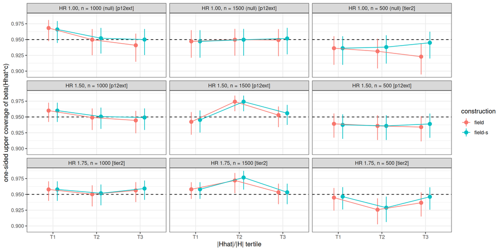

```r
P2 <- F2[grepl("^\\|Hhat", F2$stratum), ]; P2$tertile <- sub(" \\[.*", "", sub("^\\|Hhat\\|/\\|H\\| ", "", P2$stratum))
P2l <- rbind(data.frame(cell = P2$cell, tertile = P2$tertile, construction = "field", cov = P2$field, lo = P2$field_lo, hi = P2$field_hi),
             data.frame(cell = P2$cell, tertile = P2$tertile, construction = "field-s", cov = P2$field_s, lo = P2$field_s_lo, hi = P2$field_s_hi))
ggplot(P2l, aes(x = tertile, y = cov, colour = construction, group = construction)) + geom_hline(yintercept = 0.95, linetype = 2) +
  geom_pointrange(aes(ymin = lo, ymax = hi), position = position_dodge(width = 0.4)) + geom_line(position = position_dodge(width = 0.4)) +
  facet_wrap(~ cell, ncol = 3) + labs(x = "|Hhat|/|H| tertile", y = "one-sided upper coverage of beta(Hhat^c)") + theme_bw(base_size = 11)
```

# 5 Finding 3 - The null cells (HR 1.00)

```r
kbl(F1[F1$kind == "null", c("cell", "n", "field", "field_lo", "field_hi", "field_s", "field_s_lo", "field_s_hi", "field_s_minus_field", "share_flipped_to_cover", "share_flipped_to_miss", "mean_rho_c", "lamSD_over_nSE", "lamSDs_over_nSE")],
    digits = 3, booktabs = TRUE, row.names = FALSE, caption = "The null cells: field-s against field where there is no planted harm subgroup (recorded without criterion).") |> kable_styling(font_size = 10)
```

The null cells: field-s against field where there is no planted harm subgroup (recorded without criterion).

| cell | n | field | field_lo | field_hi | field_s | field_s_lo | field_s_hi | field_s_minus_field | share_flipped_to_cover | share_flipped_to_miss | mean_rho_c | lamSD_over_nSE | lamSDs_over_nSE |
| --- | --- | --- | --- | --- | --- | --- | --- | --- | --- | --- | --- | --- | --- |
| HR 1.00, n = 500 (null) [tier2] | 1361 | 0.930 | 0.915 | 0.943 | 0.940 | 0.926 | 0.951 | 0.010 | 0.011 | 0.001 | 1.02 | 0.975 | 0.993 |
| HR 1.00, n = 1000 (null) [p12ext] | 1319 | 0.953 | 0.940 | 0.963 | 0.956 | 0.944 | 0.966 | 0.003 | 0.004 | 0.001 | 1.01 | 0.982 | 0.991 |
| HR 1.00, n = 1500 (null) [p12ext] | 1248 | 0.949 | 0.935 | 0.960 | 0.950 | 0.936 | 0.960 | 0.001 | 0.001 | 0.000 | 1.01 | 0.984 | 0.993 |

# 6 Finding 4 - Bound locations and the joint pair

```r
LOC <- do.call(rbind, lapply(names(B), function(k) { d <- B[[k]]$e1$results; d <- d[d$detected %in% 1L, ]
  rows <- list(naive = list(lo = exp(log(d$nv_H_est) - qnorm(.95) * d$nv_H_se), up = exp(log(d$nv_Hc_est) + qnorm(.95) * d$nv_Hc_se)),
               `IJ two-term` = list(lo = exp(log(d$mr_H_est) - qnorm(.95) * d$mr_H_se_ij), up = exp(log(d$mr_Hc_est) + qnorm(.95) * d$mr_Hc_se_ij)),
               field = list(lo = d$fld_H_lo1s, up = d$fld_Hc_up1s), `field-s` = list(lo = d$fld_H_lo1s, up = d$fld_Hc_up1s_s))
  do.call(rbind, lapply(names(rows), function(nm) { p <- rows[[nm]]; ok <- is.finite(p$lo) & is.finite(p$up)
    data.frame(cell = labs[[k]], construction = nm, mean_betaH = mean(d$betaHhat_H), mean_betaHc = mean(d$betaHhat_Hc),
               H_lower_mean = mean(p$lo[ok]), share_ge_085 = mean(p$lo[ok] >= 0.85), share_ge_095 = mean(p$lo[ok] >= 0.95),
               Hc_upper_mean = mean(p$up[ok]), share_lt_085 = mean(p$up[ok] < 0.85), share_lt_080 = mean(p$up[ok] < 0.80),
               margin_Hc = mean(log(p$up[ok]) - log(d$mr_Hc_est[ok])), stringsAsFactors = FALSE) })) }))
kbl(LOC, digits = 3, booktabs = TRUE, row.names = FALSE, caption = "Bound locations (HR scale): the harm lower bound against 0.85 / 0.95 (field-s = field there), the complement upper bound against 0.85 / 0.80; margin_Hc = mean log(upper) - log(mr_Hc_est).") |> kable_styling(font_size = 10)
```

Bound locations (HR scale): the harm lower bound against 0.85 / 0.95 (field-s = field there), the complement upper bound against 0.85 / 0.80; margin_Hc = mean log(upper) - log(mr_Hc_est).

| cell | construction | mean_betaH | mean_betaHc | H_lower_mean | share_ge_085 | share_ge_095 | Hc_upper_mean | share_lt_085 | share_lt_080 | margin_Hc |
| --- | --- | --- | --- | --- | --- | --- | --- | --- | --- | --- |
| HR 1.50, n = 500 [p12ext] | naive | 1.041 | 0.671 | 1.082 | 0.881 | 0.673 | 0.784 | 0.744 | 0.569 | 0.162 |
| HR 1.50, n = 500 [p12ext] | IJ two-term | 1.041 | 0.671 | 0.573 | 0.064 | 0.037 | 1.016 | 0.126 | 0.053 | 0.421 |
| HR 1.50, n = 500 [p12ext] | field | 1.041 | 0.671 | 0.547 | 0.069 | 0.037 | 0.843 | 0.537 | 0.373 | 0.233 |
| HR 1.50, n = 500 [p12ext] | field-s | 1.041 | 0.671 | 0.547 | 0.069 | 0.037 | 0.845 | 0.529 | 0.373 | 0.236 |
| HR 1.50, n = 1000 [p12ext] | naive | 1.236 | 0.658 | 1.126 | 0.937 | 0.770 | 0.747 | 0.925 | 0.775 | 0.121 |
| HR 1.50, n = 1000 [p12ext] | IJ two-term | 1.236 | 0.658 | 0.730 | 0.221 | 0.129 | 0.894 | 0.311 | 0.148 | 0.300 |
| HR 1.50, n = 1000 [p12ext] | field | 1.236 | 0.658 | 0.725 | 0.221 | 0.141 | 0.778 | 0.824 | 0.622 | 0.161 |
| HR 1.50, n = 1000 [p12ext] | field-s | 1.236 | 0.658 | 0.725 | 0.221 | 0.141 | 0.779 | 0.820 | 0.610 | 0.163 |
| HR 1.50, n = 1500 [p12ext] | naive | 1.348 | 0.646 | 1.147 | 0.969 | 0.860 | 0.723 | 0.985 | 0.912 | 0.105 |
| HR 1.50, n = 1500 [p12ext] | IJ two-term | 1.348 | 0.646 | 0.829 | 0.423 | 0.218 | 0.835 | 0.600 | 0.313 | 0.248 |
| HR 1.50, n = 1500 [p12ext] | field | 1.348 | 0.646 | 0.846 | 0.434 | 0.277 | 0.743 | 0.952 | 0.827 | 0.130 |
| HR 1.50, n = 1500 [p12ext] | field-s | 1.348 | 0.646 | 0.846 | 0.434 | 0.277 | 0.744 | 0.951 | 0.820 | 0.132 |
| HR 1.75, n = 500 [tier2] | naive | 1.253 | 0.669 | 1.182 | 0.936 | 0.792 | 0.789 | 0.723 | 0.554 | 0.166 |
| HR 1.75, n = 500 [tier2] | IJ two-term | 1.253 | 0.669 | 0.644 | 0.143 | 0.088 | 1.021 | 0.116 | 0.051 | 0.423 |
| HR 1.75, n = 500 [tier2] | field | 1.253 | 0.669 | 0.623 | 0.136 | 0.093 | 0.844 | 0.542 | 0.368 | 0.232 |
| HR 1.75, n = 500 [tier2] | field-s | 1.253 | 0.669 | 0.623 | 0.136 | 0.093 | 0.846 | 0.531 | 0.361 | 0.235 |
| HR 1.75, n = 1000 [tier2] | naive | 1.523 | 0.653 | 1.281 | 0.977 | 0.914 | 0.749 | 0.916 | 0.764 | 0.127 |
| HR 1.75, n = 1000 [tier2] | IJ two-term | 1.523 | 0.653 | 0.857 | 0.449 | 0.302 | 0.893 | 0.316 | 0.149 | 0.303 |
| HR 1.75, n = 1000 [tier2] | field | 1.523 | 0.653 | 0.876 | 0.434 | 0.308 | 0.774 | 0.833 | 0.640 | 0.160 |
| HR 1.75, n = 1000 [tier2] | field-s | 1.523 | 0.653 | 0.876 | 0.434 | 0.308 | 0.776 | 0.829 | 0.638 | 0.161 |
| HR 1.75, n = 1500 [tier2] | naive | 1.629 | 0.642 | 1.322 | 0.995 | 0.970 | 0.724 | 0.982 | 0.911 | 0.111 |
| HR 1.75, n = 1500 [tier2] | IJ two-term | 1.629 | 0.642 | 0.978 | 0.738 | 0.550 | 0.833 | 0.611 | 0.326 | 0.251 |
| HR 1.75, n = 1500 [tier2] | field | 1.629 | 0.642 | 1.044 | 0.736 | 0.591 | 0.738 | 0.964 | 0.852 | 0.129 |
| HR 1.75, n = 1500 [tier2] | field-s | 1.629 | 0.642 | 1.044 | 0.736 | 0.591 | 0.739 | 0.962 | 0.850 | 0.130 |
| HR 1.00, n = 500 (null) [tier2] | naive | 0.719 | 0.661 | 0.953 | 0.712 | 0.403 | 0.765 | 0.806 | 0.646 | 0.160 |
| HR 1.00, n = 500 (null) [tier2] | IJ two-term | 0.719 | 0.661 | 0.482 | 0.007 | 0.004 | 0.992 | 0.146 | 0.076 | 0.419 |
| HR 1.00, n = 500 (null) [tier2] | field | 0.719 | 0.661 | 0.450 | 0.011 | 0.004 | 0.827 | 0.591 | 0.408 | 0.236 |
| HR 1.00, n = 500 (null) [tier2] | field-s | 0.719 | 0.661 | 0.450 | 0.011 | 0.004 | 0.829 | 0.580 | 0.400 | 0.239 |
| HR 1.00, n = 1000 (null) [p12ext] | naive | 0.766 | 0.657 | 0.920 | 0.671 | 0.293 | 0.739 | 0.946 | 0.818 | 0.115 |
| HR 1.00, n = 1000 (null) [p12ext] | IJ two-term | 0.766 | 0.657 | 0.561 | 0.020 | 0.005 | 0.886 | 0.343 | 0.148 | 0.295 |
| HR 1.00, n = 1000 (null) [p12ext] | field | 0.766 | 0.657 | 0.538 | 0.025 | 0.010 | 0.777 | 0.833 | 0.627 | 0.164 |
| HR 1.00, n = 1000 (null) [p12ext] | field-s | 0.766 | 0.657 | 0.538 | 0.025 | 0.010 | 0.778 | 0.830 | 0.622 | 0.164 |
| HR 1.00, n = 1500 (null) [p12ext] | naive | 0.810 | 0.651 | 0.896 | 0.608 | 0.212 | 0.719 | 0.990 | 0.942 | 0.096 |
| HR 1.00, n = 1500 (null) [p12ext] | IJ two-term | 0.810 | 0.651 | 0.610 | 0.021 | 0.006 | 0.831 | 0.623 | 0.315 | 0.241 |
| HR 1.00, n = 1500 (null) [p12ext] | field | 0.810 | 0.651 | 0.582 | 0.030 | 0.011 | 0.746 | 0.965 | 0.821 | 0.133 |
| HR 1.00, n = 1500 (null) [p12ext] | field-s | 0.810 | 0.651 | 0.582 | 0.030 | 0.011 | 0.747 | 0.965 | 0.820 | 0.134 |

```r
JNT <- do.call(rbind, lapply(names(B), function(k) { r <- B[[k]]$e1$results
  d <- r[r$detected %in% 1L & is.finite(r$betaHhat_H) & is.finite(r$betaHhat_Hc) & is.finite(r$fld_joint_gamma) & is.finite(r$fld_joint_s_gamma), ]
  pairs <- list(`separate 95% (field)` = list(lo = d$fld_H_lo1s, up = d$fld_Hc_up1s, g = NA, cr = NA), `separate 95% (field-s)` = list(lo = d$fld_H_lo1s, up = d$fld_Hc_up1s_s, g = NA, cr = NA),
                `Bonferroni (joint)` = list(lo = d$fld_joint_bonf_loH, up = d$fld_joint_bonf_upHc, g = 0.025, cr = d$fld_joint_corr), `Bonferroni (joint_s)` = list(lo = d$fld_joint_s_bonf_loH, up = d$fld_joint_s_bonf_upHc, g = 0.025, cr = d$fld_joint_s_corr),
                `calibrated (joint)` = list(lo = d$fld_joint_loH, up = d$fld_joint_upHc, g = d$fld_joint_gamma, cr = d$fld_joint_corr), `calibrated (joint_s)` = list(lo = d$fld_joint_s_loH, up = d$fld_joint_s_upHc, g = d$fld_joint_s_gamma, cr = d$fld_joint_s_corr))
  do.call(rbind, lapply(names(pairs), function(nm) { p <- pairs[[nm]]; cH <- d$betaHhat_H >= p$lo; cC <- d$betaHhat_Hc <= p$up; jc <- mean(cH & cC); w <- wil(jc, nrow(d))
    data.frame(cell = labs[[k]], pair = nm, n = nrow(d), joint_cov = jc, wilson_lo = w[1], wilson_hi = w[2], cov_H = mean(cH), cov_Hc = mean(cC),
               margin_H = mean(log(d$mr_H_est) - log(p$lo)), margin_Hc = mean(log(p$up) - log(d$mr_Hc_est)), mean_gamma = mean(p$g), mean_corr = mean(p$cr), stringsAsFactors = FALSE) })) }))
kbl(JNT, digits = 3, booktabs = TRUE, row.names = FALSE, caption = "Joint coverage of (beta(Hhat) >= lower_H, beta(Hhat^c) <= upper_Hc), Wilson limits: the separate 95% bounds, the Bonferroni pair and the calibrated pair, from the unscaled joint and from joint_s.") |> kable_styling(font_size = 9)
```

Joint coverage of (beta(Hhat) >= lower_H, beta(Hhat^c) <= upper_Hc), Wilson limits: the separate 95% bounds, the Bonferroni pair and the calibrated pair, from the unscaled joint and from joint_s.

| cell | pair | n | joint_cov | wilson_lo | wilson_hi | cov_H | cov_Hc | margin_H | margin_Hc | mean_gamma | mean_corr |
| --- | --- | --- | --- | --- | --- | --- | --- | --- | --- | --- | --- |
| HR 1.50, n = 500 [p12ext] | separate 95% (field) | 1822 | 0.905 | 0.891 | 0.918 | 0.965 | 0.936 | 0.710 | 0.233 | NA | NA |
| HR 1.50, n = 500 [p12ext] | separate 95% (field-s) | 1822 | 0.906 | 0.892 | 0.919 | 0.965 | 0.937 | 0.710 | 0.236 | NA | NA |
| HR 1.50, n = 500 [p12ext] | Bonferroni (joint) | 1822 | 0.953 | 0.942 | 0.962 | 0.990 | 0.963 | 0.858 | 0.276 | 0.025 | 0.030 |
| HR 1.50, n = 500 [p12ext] | Bonferroni (joint_s) | 1822 | 0.956 | 0.945 | 0.964 | 0.990 | 0.965 | 0.858 | 0.279 | 0.025 | 0.026 |
| HR 1.50, n = 500 [p12ext] | calibrated (joint) | 1822 | 0.953 | 0.942 | 0.962 | 0.990 | 0.963 | 0.858 | 0.276 | 0.025 | 0.030 |
| HR 1.50, n = 500 [p12ext] | calibrated (joint_s) | 1822 | 0.956 | 0.945 | 0.964 | 0.990 | 0.965 | 0.858 | 0.279 | 0.025 | 0.026 |
| HR 1.50, n = 1000 [p12ext] | separate 95% (field) | 1948 | 0.894 | 0.879 | 0.907 | 0.941 | 0.951 | 0.511 | 0.161 | NA | NA |
| HR 1.50, n = 1000 [p12ext] | separate 95% (field-s) | 1948 | 0.896 | 0.881 | 0.909 | 0.941 | 0.953 | 0.511 | 0.163 | NA | NA |
| HR 1.50, n = 1000 [p12ext] | Bonferroni (joint) | 1948 | 0.943 | 0.931 | 0.952 | 0.968 | 0.975 | 0.618 | 0.191 | 0.025 | -0.008 |
| HR 1.50, n = 1000 [p12ext] | Bonferroni (joint_s) | 1948 | 0.944 | 0.932 | 0.953 | 0.968 | 0.976 | 0.618 | 0.193 | 0.025 | -0.011 |
| HR 1.50, n = 1000 [p12ext] | calibrated (joint) | 1948 | 0.942 | 0.931 | 0.952 | 0.968 | 0.974 | 0.618 | 0.191 | 0.025 | -0.008 |
| HR 1.50, n = 1000 [p12ext] | calibrated (joint_s) | 1948 | 0.943 | 0.931 | 0.952 | 0.967 | 0.975 | 0.617 | 0.193 | 0.025 | -0.011 |
| HR 1.50, n = 1500 [p12ext] | separate 95% (field) | 1976 | 0.916 | 0.903 | 0.927 | 0.956 | 0.956 | 0.398 | 0.130 | NA | NA |
| HR 1.50, n = 1500 [p12ext] | separate 95% (field-s) | 1976 | 0.918 | 0.905 | 0.929 | 0.956 | 0.959 | 0.398 | 0.132 | NA | NA |
| HR 1.50, n = 1500 [p12ext] | Bonferroni (joint) | 1976 | 0.957 | 0.947 | 0.965 | 0.974 | 0.982 | 0.484 | 0.155 | 0.025 | -0.049 |
| HR 1.50, n = 1500 [p12ext] | Bonferroni (joint_s) | 1976 | 0.958 | 0.948 | 0.966 | 0.974 | 0.983 | 0.484 | 0.156 | 0.025 | -0.053 |
| HR 1.50, n = 1500 [p12ext] | calibrated (joint) | 1976 | 0.957 | 0.947 | 0.965 | 0.974 | 0.982 | 0.483 | 0.155 | 0.025 | -0.049 |
| HR 1.50, n = 1500 [p12ext] | calibrated (joint_s) | 1976 | 0.958 | 0.948 | 0.966 | 0.974 | 0.983 | 0.483 | 0.156 | 0.025 | -0.053 |
| HR 1.75, n = 500 [tier2] | separate 95% (field) | 1900 | 0.905 | 0.891 | 0.918 | 0.966 | 0.936 | 0.699 | 0.232 | NA | NA |
| HR 1.75, n = 500 [tier2] | separate 95% (field-s) | 1900 | 0.910 | 0.896 | 0.922 | 0.966 | 0.941 | 0.699 | 0.235 | NA | NA |
| HR 1.75, n = 500 [tier2] | Bonferroni (joint) | 1900 | 0.956 | 0.946 | 0.964 | 0.990 | 0.965 | 0.847 | 0.275 | 0.025 | 0.014 |
| HR 1.75, n = 500 [tier2] | Bonferroni (joint_s) | 1900 | 0.957 | 0.947 | 0.965 | 0.990 | 0.966 | 0.847 | 0.278 | 0.025 | 0.010 |
| HR 1.75, n = 500 [tier2] | calibrated (joint) | 1900 | 0.956 | 0.946 | 0.964 | 0.990 | 0.965 | 0.846 | 0.275 | 0.025 | 0.014 |
| HR 1.75, n = 500 [tier2] | calibrated (joint_s) | 1900 | 0.957 | 0.947 | 0.965 | 0.990 | 0.966 | 0.846 | 0.278 | 0.025 | 0.010 |
| HR 1.75, n = 1000 [tier2] | separate 95% (field) | 1990 | 0.901 | 0.887 | 0.913 | 0.944 | 0.955 | 0.493 | 0.160 | NA | NA |
| HR 1.75, n = 1000 [tier2] | separate 95% (field-s) | 1990 | 0.903 | 0.889 | 0.915 | 0.944 | 0.956 | 0.493 | 0.161 | NA | NA |
| HR 1.75, n = 1000 [tier2] | Bonferroni (joint) | 1990 | 0.941 | 0.930 | 0.951 | 0.965 | 0.976 | 0.600 | 0.190 | 0.025 | -0.038 |
| HR 1.75, n = 1000 [tier2] | Bonferroni (joint_s) | 1990 | 0.941 | 0.930 | 0.951 | 0.965 | 0.976 | 0.600 | 0.191 | 0.025 | -0.041 |
| HR 1.75, n = 1000 [tier2] | calibrated (joint) | 1990 | 0.941 | 0.930 | 0.951 | 0.965 | 0.976 | 0.599 | 0.189 | 0.025 | -0.038 |
| HR 1.75, n = 1000 [tier2] | calibrated (joint_s) | 1990 | 0.941 | 0.930 | 0.951 | 0.965 | 0.976 | 0.599 | 0.191 | 0.025 | -0.041 |
| HR 1.75, n = 1500 [tier2] | separate 95% (field) | 1998 | 0.923 | 0.911 | 0.934 | 0.960 | 0.959 | 0.374 | 0.129 | NA | NA |
| HR 1.75, n = 1500 [tier2] | separate 95% (field-s) | 1998 | 0.924 | 0.912 | 0.935 | 0.960 | 0.960 | 0.374 | 0.130 | NA | NA |
| HR 1.75, n = 1500 [tier2] | Bonferroni (joint) | 1998 | 0.963 | 0.954 | 0.971 | 0.981 | 0.981 | 0.460 | 0.154 | 0.025 | -0.081 |
| HR 1.75, n = 1500 [tier2] | Bonferroni (joint_s) | 1998 | 0.964 | 0.955 | 0.971 | 0.981 | 0.982 | 0.460 | 0.155 | 0.025 | -0.084 |
| HR 1.75, n = 1500 [tier2] | calibrated (joint) | 1998 | 0.963 | 0.954 | 0.971 | 0.981 | 0.981 | 0.459 | 0.154 | 0.025 | -0.081 |
| HR 1.75, n = 1500 [tier2] | calibrated (joint_s) | 1998 | 0.964 | 0.955 | 0.971 | 0.981 | 0.982 | 0.459 | 0.155 | 0.025 | -0.084 |
| HR 1.00, n = 500 (null) [tier2] | separate 95% (field) | 1361 | 0.894 | 0.877 | 0.909 | 0.963 | 0.930 | 0.734 | 0.236 | NA | NA |
| HR 1.00, n = 500 (null) [tier2] | separate 95% (field-s) | 1361 | 0.904 | 0.887 | 0.918 | 0.963 | 0.940 | 0.734 | 0.239 | NA | NA |
| HR 1.00, n = 500 (null) [tier2] | Bonferroni (joint) | 1361 | 0.955 | 0.943 | 0.965 | 0.988 | 0.967 | 0.883 | 0.279 | 0.025 | 0.047 |
| HR 1.00, n = 500 (null) [tier2] | Bonferroni (joint_s) | 1361 | 0.957 | 0.944 | 0.966 | 0.988 | 0.968 | 0.883 | 0.283 | 0.025 | 0.043 |
| HR 1.00, n = 500 (null) [tier2] | calibrated (joint) | 1361 | 0.955 | 0.943 | 0.965 | 0.988 | 0.967 | 0.883 | 0.279 | 0.025 | 0.047 |
| HR 1.00, n = 500 (null) [tier2] | calibrated (joint_s) | 1361 | 0.957 | 0.944 | 0.966 | 0.988 | 0.968 | 0.883 | 0.282 | 0.025 | 0.043 |
| HR 1.00, n = 1000 (null) [p12ext] | separate 95% (field) | 1319 | 0.876 | 0.858 | 0.893 | 0.920 | 0.953 | 0.542 | 0.164 | NA | NA |
| HR 1.00, n = 1000 (null) [p12ext] | separate 95% (field-s) | 1319 | 0.879 | 0.861 | 0.896 | 0.920 | 0.956 | 0.542 | 0.164 | NA | NA |
| HR 1.00, n = 1000 (null) [p12ext] | Bonferroni (joint) | 1319 | 0.940 | 0.926 | 0.952 | 0.961 | 0.978 | 0.650 | 0.194 | 0.025 | 0.038 |
| HR 1.00, n = 1000 (null) [p12ext] | Bonferroni (joint_s) | 1319 | 0.942 | 0.928 | 0.953 | 0.961 | 0.980 | 0.650 | 0.195 | 0.025 | 0.034 |
| HR 1.00, n = 1000 (null) [p12ext] | calibrated (joint) | 1319 | 0.940 | 0.926 | 0.952 | 0.961 | 0.978 | 0.650 | 0.194 | 0.025 | 0.038 |
| HR 1.00, n = 1000 (null) [p12ext] | calibrated (joint_s) | 1319 | 0.942 | 0.928 | 0.953 | 0.961 | 0.980 | 0.650 | 0.195 | 0.025 | 0.034 |
| HR 1.00, n = 1500 (null) [p12ext] | separate 95% (field) | 1248 | 0.881 | 0.862 | 0.898 | 0.930 | 0.949 | 0.437 | 0.133 | NA | NA |
| HR 1.00, n = 1500 (null) [p12ext] | separate 95% (field-s) | 1248 | 0.882 | 0.863 | 0.899 | 0.930 | 0.950 | 0.437 | 0.134 | NA | NA |
| HR 1.00, n = 1500 (null) [p12ext] | Bonferroni (joint) | 1248 | 0.943 | 0.929 | 0.955 | 0.968 | 0.974 | 0.523 | 0.157 | 0.025 | 0.019 |
| HR 1.00, n = 1500 (null) [p12ext] | Bonferroni (joint_s) | 1248 | 0.943 | 0.929 | 0.955 | 0.968 | 0.974 | 0.523 | 0.158 | 0.025 | 0.015 |
| HR 1.00, n = 1500 (null) [p12ext] | calibrated (joint) | 1248 | 0.943 | 0.929 | 0.955 | 0.968 | 0.974 | 0.523 | 0.157 | 0.025 | 0.019 |
| HR 1.00, n = 1500 (null) [p12ext] | calibrated (joint_s) | 1248 | 0.943 | 0.929 | 0.955 | 0.968 | 0.974 | 0.523 | 0.158 | 0.025 | 0.015 |

# 7 Finding 5 - R1 vs the global rescale: `se_field_s / (rho^c x se_field)` per cell (informational)

```r
F5 <- do.call(rbind, lapply(names(B), function(k) { r <- B[[k]]$e1$results; d <- r[r$detected %in% 1L & is.finite(r$fld_Hc_se_s) & is.finite(r$fld_Hc_scale_ratio), ]
  v <- d$fld_Hc_se_s / (d$fld_Hc_scale_ratio * d$fld_Hc_se); q <- quantile(v, c(.01, .10, .50, .90, .99))
  data.frame(cell = labs[[k]], n = nrow(d), mean = mean(v), sd = sd(v), q01 = q[1], q10 = q[2], q50 = q[3], q90 = q[4], q99 = q[5], min = min(v), max = max(v),
             mean_scale_cv = mean(d$fld_Hc_scale_cv), q90_scale_cv = quantile(d$fld_Hc_scale_cv, .9), mean_rho_c = mean(d$fld_Hc_scale_ratio), share_rho_gt_1 = mean(d$fld_Hc_scale_ratio > 1),
             corr_flds_nv = cor(d$fld_Hc_se_s, d$nv_Hc_se), corr_fld_nv = cor(d$fld_Hc_se, d$nv_Hc_se)) }))
kbl(F5, digits = 4, booktabs = TRUE, row.names = FALSE, caption = "The per-draw (R1) studentized SD against the global rescale rho^c x lambda-SD^c, per cell; the winner-scale CV; rho^c; and the per-replicate correlation of each field SD with the naive SE.") |> kable_styling(font_size = 9)
```

The per-draw (R1) studentized SD against the global rescale rho^c x lambda-SD^c, per cell; the winner-scale CV; rho^c; and the per-replicate correlation of each field SD with the naive SE.

| cell | n | mean | sd | q01 | q10 | q50 | q90 | q99 | min | max | mean_scale_cv | q90_scale_cv | mean_rho_c | share_rho_gt_1 | corr_flds_nv | corr_fld_nv |
| --- | --- | --- | --- | --- | --- | --- | --- | --- | --- | --- | --- | --- | --- | --- | --- | --- |
| HR 1.50, n = 500 [p12ext] | 1822 | 0.9992 | 0.0019 | 0.9941 | 0.9967 | 0.9992 | 1.0014 | 1.0030 | 0.9901 | 1.0051 | 0.0277 | 0.0356 | 1.0163 | 0.7832 | 0.7954 | 0.5446 |
| HR 1.50, n = 1000 [p12ext] | 1948 | 0.9999 | 0.0014 | 0.9961 | 0.9981 | 1.0000 | 1.0016 | 1.0029 | 0.9938 | 1.0075 | 0.0232 | 0.0304 | 1.0102 | 0.7305 | 0.7434 | 0.4634 |
| HR 1.50, n = 1500 [p12ext] | 1976 | 1.0004 | 0.0012 | 0.9971 | 0.9988 | 1.0005 | 1.0018 | 1.0032 | 0.9952 | 1.0045 | 0.0216 | 0.0290 | 1.0103 | 0.7687 | 0.6929 | 0.4264 |
| HR 1.75, n = 500 [tier2] | 1900 | 0.9996 | 0.0018 | 0.9950 | 0.9971 | 0.9997 | 1.0018 | 1.0035 | 0.9920 | 1.0063 | 0.0273 | 0.0356 | 1.0166 | 0.7895 | 0.7967 | 0.5590 |
| HR 1.75, n = 1000 [tier2] | 1990 | 1.0003 | 0.0013 | 0.9967 | 0.9987 | 1.0004 | 1.0019 | 1.0034 | 0.9935 | 1.0068 | 0.0224 | 0.0302 | 1.0105 | 0.7598 | 0.7380 | 0.4984 |
| HR 1.75, n = 1500 [tier2] | 1998 | 1.0006 | 0.0011 | 0.9978 | 0.9993 | 1.0006 | 1.0019 | 1.0032 | 0.9946 | 1.0043 | 0.0197 | 0.0282 | 1.0095 | 0.8013 | 0.6710 | 0.4635 |
| HR 1.00, n = 500 (null) [tier2] | 1361 | 0.9984 | 0.0019 | 0.9927 | 0.9959 | 0.9985 | 1.0008 | 1.0023 | 0.9894 | 1.0042 | 0.0274 | 0.0357 | 1.0196 | 0.7627 | 0.8387 | 0.4885 |
| HR 1.00, n = 1000 (null) [p12ext] | 1319 | 0.9989 | 0.0017 | 0.9941 | 0.9967 | 0.9990 | 1.0008 | 1.0023 | 0.9898 | 1.0039 | 0.0235 | 0.0306 | 1.0100 | 0.6224 | 0.7578 | 0.3705 |
| HR 1.00, n = 1500 (null) [p12ext] | 1248 | 0.9993 | 0.0015 | 0.9952 | 0.9974 | 0.9994 | 1.0010 | 1.0023 | 0.9939 | 1.0039 | 0.0232 | 0.0300 | 1.0101 | 0.6554 | 0.7132 | 0.2531 |

# 8 Numbers for the record

**Finding 1 (complement upper coverage; field / field-s / IJ, Wilson):**

- HR 1.50, n = 500 [p12ext] (n 1822): field 0.936 [0.924, 0.947]; field-s 0.937 [0.925, 0.948]; IJ 0.997 [0.993, 0.998]; flips to cover 0.003, to miss 0.002; mean rho^c 1.016; lambda-SD/nSE 0.980 -> 0.995
- HR 1.50, n = 1000 [p12ext] (n 1948): field 0.951 [0.941, 0.960]; field-s 0.953 [0.943, 0.962]; IJ 0.999 [0.997, 1.000]; flips to cover 0.002, to miss 0.000; mean rho^c 1.010; lambda-SD/nSE 0.990 -> 1.000
- HR 1.50, n = 1500 [p12ext] (n 1976): field 0.956 [0.947, 0.965]; field-s 0.959 [0.949, 0.966]; IJ 0.999 [0.996, 1.000]; flips to cover 0.002, to miss 0.000; mean rho^c 1.010; lambda-SD/nSE 0.997 -> 1.008
- HR 1.75, n = 500 [tier2] (n 1900): field 0.936 [0.924, 0.946]; field-s 0.941 [0.929, 0.950]; IJ 0.999 [0.996, 1.000]; flips to cover 0.005, to miss 0.000; mean rho^c 1.017; lambda-SD/nSE 0.982 -> 0.998
- HR 1.75, n = 1000 [tier2] (n 1990): field 0.955 [0.945, 0.963]; field-s 0.956 [0.946, 0.964]; IJ 0.998 [0.996, 0.999]; flips to cover 0.002, to miss 0.001; mean rho^c 1.010; lambda-SD/nSE 0.995 -> 1.006
- HR 1.75, n = 1500 [tier2] (n 1998): field 0.959 [0.950, 0.967]; field-s 0.960 [0.951, 0.968]; IJ 0.999 [0.996, 1.000]; flips to cover 0.001, to miss 0.000; mean rho^c 1.010; lambda-SD/nSE 1.005 -> 1.015
- HR 1.00, n = 500 (null) [tier2] (n 1361): field 0.930 [0.915, 0.943]; field-s 0.940 [0.926, 0.951]; IJ 0.997 [0.992, 0.999]; flips to cover 0.011, to miss 0.001; mean rho^c 1.020; lambda-SD/nSE 0.975 -> 0.993
- HR 1.00, n = 1000 (null) [p12ext] (n 1319): field 0.953 [0.940, 0.963]; field-s 0.956 [0.944, 0.966]; IJ 0.998 [0.993, 0.999]; flips to cover 0.004, to miss 0.001; mean rho^c 1.010; lambda-SD/nSE 0.982 -> 0.991
- HR 1.00, n = 1500 (null) [p12ext] (n 1248): field 0.949 [0.935, 0.960]; field-s 0.950 [0.936, 0.960]; IJ 0.999 [0.995, 1.000]; flips to cover 0.001, to miss 0.000; mean rho^c 1.010; lambda-SD/nSE 0.984 -> 0.993

**Finding 2 (shape; |Hhat|/|H| tertiles T1/T2/T3, field -> field-s):**

- HR 1.50, n = 500 [p12ext]: field 0.939 / 0.936 / 0.934; field-s 0.938 / 0.936 / 0.939; rho^c 1.010 / 1.013 / 1.026
- HR 1.50, n = 1000 [p12ext]: field 0.960 / 0.949 / 0.945; field-s 0.960 / 0.951 / 0.949; rho^c 1.000 / 1.012 / 1.019
- HR 1.50, n = 1500 [p12ext]: field 0.942 / 0.974 / 0.953; field-s 0.945 / 0.974 / 0.956; rho^c 0.998 / 1.015 / 1.018
- HR 1.75, n = 500 [tier2]: field 0.945 / 0.926 / 0.937; field-s 0.946 / 0.929 / 0.946; rho^c 1.012 / 1.014 / 1.024
- HR 1.75, n = 1000 [tier2]: field 0.958 / 0.950 / 0.956; field-s 0.958 / 0.952 / 0.959; rho^c 1.000 / 1.013 / 1.019
- HR 1.75, n = 1500 [tier2]: field 0.958 / 0.972 / 0.953; field-s 0.958 / 0.977 / 0.953; rho^c 1.003 / 1.014 / 1.016
- HR 1.00, n = 500 (null) [tier2]: field 0.936 / 0.931 / 0.923; field-s 0.936 / 0.938 / 0.945; rho^c 1.007 / 1.013 / 1.039
- HR 1.00, n = 1000 (null) [p12ext]: field 0.968 / 0.950 / 0.941; field-s 0.966 / 0.952 / 0.950; rho^c 0.999 / 1.007 / 1.024
- HR 1.00, n = 1500 (null) [p12ext]: field 0.947 / 0.950 / 0.949; field-s 0.947 / 0.950 / 0.952; rho^c 0.998 / 1.007 / 1.025

**Finding 4 (complement upper bound mean; shares < 0.85 / < 0.80):**

- HR 1.50, n = 500 [p12ext], naive: Hc upper mean 0.784; < 0.85 0.744; < 0.80 0.569; margin 0.162
- HR 1.50, n = 500 [p12ext], IJ two-term: Hc upper mean 1.016; < 0.85 0.126; < 0.80 0.053; margin 0.421
- HR 1.50, n = 500 [p12ext], field: Hc upper mean 0.843; < 0.85 0.537; < 0.80 0.373; margin 0.233
- HR 1.50, n = 500 [p12ext], field-s: Hc upper mean 0.845; < 0.85 0.529; < 0.80 0.373; margin 0.236
- HR 1.50, n = 1000 [p12ext], naive: Hc upper mean 0.747; < 0.85 0.925; < 0.80 0.775; margin 0.121
- HR 1.50, n = 1000 [p12ext], IJ two-term: Hc upper mean 0.894; < 0.85 0.311; < 0.80 0.148; margin 0.300
- HR 1.50, n = 1000 [p12ext], field: Hc upper mean 0.778; < 0.85 0.824; < 0.80 0.622; margin 0.161
- HR 1.50, n = 1000 [p12ext], field-s: Hc upper mean 0.779; < 0.85 0.820; < 0.80 0.610; margin 0.163
- HR 1.50, n = 1500 [p12ext], naive: Hc upper mean 0.723; < 0.85 0.985; < 0.80 0.912; margin 0.105
- HR 1.50, n = 1500 [p12ext], IJ two-term: Hc upper mean 0.835; < 0.85 0.600; < 0.80 0.313; margin 0.248
- HR 1.50, n = 1500 [p12ext], field: Hc upper mean 0.743; < 0.85 0.952; < 0.80 0.827; margin 0.130
- HR 1.50, n = 1500 [p12ext], field-s: Hc upper mean 0.744; < 0.85 0.951; < 0.80 0.820; margin 0.132
- HR 1.75, n = 500 [tier2], naive: Hc upper mean 0.789; < 0.85 0.723; < 0.80 0.554; margin 0.166
- HR 1.75, n = 500 [tier2], IJ two-term: Hc upper mean 1.021; < 0.85 0.116; < 0.80 0.051; margin 0.423
- HR 1.75, n = 500 [tier2], field: Hc upper mean 0.844; < 0.85 0.542; < 0.80 0.368; margin 0.232
- HR 1.75, n = 500 [tier2], field-s: Hc upper mean 0.846; < 0.85 0.531; < 0.80 0.361; margin 0.235
- HR 1.75, n = 1000 [tier2], naive: Hc upper mean 0.749; < 0.85 0.916; < 0.80 0.764; margin 0.127
- HR 1.75, n = 1000 [tier2], IJ two-term: Hc upper mean 0.893; < 0.85 0.316; < 0.80 0.149; margin 0.303
- HR 1.75, n = 1000 [tier2], field: Hc upper mean 0.774; < 0.85 0.833; < 0.80 0.640; margin 0.160
- HR 1.75, n = 1000 [tier2], field-s: Hc upper mean 0.776; < 0.85 0.829; < 0.80 0.638; margin 0.161
- HR 1.75, n = 1500 [tier2], naive: Hc upper mean 0.724; < 0.85 0.982; < 0.80 0.911; margin 0.111
- HR 1.75, n = 1500 [tier2], IJ two-term: Hc upper mean 0.833; < 0.85 0.611; < 0.80 0.326; margin 0.251
- HR 1.75, n = 1500 [tier2], field: Hc upper mean 0.738; < 0.85 0.964; < 0.80 0.852; margin 0.129
- HR 1.75, n = 1500 [tier2], field-s: Hc upper mean 0.739; < 0.85 0.962; < 0.80 0.850; margin 0.130
- HR 1.00, n = 500 (null) [tier2], naive: Hc upper mean 0.765; < 0.85 0.806; < 0.80 0.646; margin 0.160
- HR 1.00, n = 500 (null) [tier2], IJ two-term: Hc upper mean 0.992; < 0.85 0.146; < 0.80 0.076; margin 0.419
- HR 1.00, n = 500 (null) [tier2], field: Hc upper mean 0.827; < 0.85 0.591; < 0.80 0.408; margin 0.236
- HR 1.00, n = 500 (null) [tier2], field-s: Hc upper mean 0.829; < 0.85 0.580; < 0.80 0.400; margin 0.239
- HR 1.00, n = 1000 (null) [p12ext], naive: Hc upper mean 0.739; < 0.85 0.946; < 0.80 0.818; margin 0.115
- HR 1.00, n = 1000 (null) [p12ext], IJ two-term: Hc upper mean 0.886; < 0.85 0.343; < 0.80 0.148; margin 0.295
- HR 1.00, n = 1000 (null) [p12ext], field: Hc upper mean 0.777; < 0.85 0.833; < 0.80 0.627; margin 0.164
- HR 1.00, n = 1000 (null) [p12ext], field-s: Hc upper mean 0.778; < 0.85 0.830; < 0.80 0.622; margin 0.164
- HR 1.00, n = 1500 (null) [p12ext], naive: Hc upper mean 0.719; < 0.85 0.990; < 0.80 0.942; margin 0.096
- HR 1.00, n = 1500 (null) [p12ext], IJ two-term: Hc upper mean 0.831; < 0.85 0.623; < 0.80 0.315; margin 0.241
- HR 1.00, n = 1500 (null) [p12ext], field: Hc upper mean 0.746; < 0.85 0.965; < 0.80 0.821; margin 0.133
- HR 1.00, n = 1500 (null) [p12ext], field-s: Hc upper mean 0.747; < 0.85 0.965; < 0.80 0.820; margin 0.134

**Finding 5 (R1 vs global):**

- HR 1.50, n = 500 [p12ext]: mean 0.9992 sd 0.0019 [q01 0.9941, q99 1.0030]; scale CV mean 0.028 q90 0.036; corr(se_s, nSE) 0.795 vs corr(se, nSE) 0.545
- HR 1.50, n = 1000 [p12ext]: mean 0.9999 sd 0.0014 [q01 0.9961, q99 1.0029]; scale CV mean 0.023 q90 0.030; corr(se_s, nSE) 0.743 vs corr(se, nSE) 0.463
- HR 1.50, n = 1500 [p12ext]: mean 1.0004 sd 0.0012 [q01 0.9971, q99 1.0032]; scale CV mean 0.022 q90 0.029; corr(se_s, nSE) 0.693 vs corr(se, nSE) 0.426
- HR 1.75, n = 500 [tier2]: mean 0.9996 sd 0.0018 [q01 0.9950, q99 1.0035]; scale CV mean 0.027 q90 0.036; corr(se_s, nSE) 0.797 vs corr(se, nSE) 0.559
- HR 1.75, n = 1000 [tier2]: mean 1.0003 sd 0.0013 [q01 0.9967, q99 1.0034]; scale CV mean 0.022 q90 0.030; corr(se_s, nSE) 0.738 vs corr(se, nSE) 0.498
- HR 1.75, n = 1500 [tier2]: mean 1.0006 sd 0.0011 [q01 0.9978, q99 1.0032]; scale CV mean 0.020 q90 0.028; corr(se_s, nSE) 0.671 vs corr(se, nSE) 0.464
- HR 1.00, n = 500 (null) [tier2]: mean 0.9984 sd 0.0019 [q01 0.9927, q99 1.0023]; scale CV mean 0.027 q90 0.036; corr(se_s, nSE) 0.839 vs corr(se, nSE) 0.489
- HR 1.00, n = 1000 (null) [p12ext]: mean 0.9989 sd 0.0017 [q01 0.9941, q99 1.0023]; scale CV mean 0.024 q90 0.031; corr(se_s, nSE) 0.758 vs corr(se, nSE) 0.371
- HR 1.00, n = 1500 (null) [p12ext]: mean 0.9993 sd 0.0015 [q01 0.9952, q99 1.0023]; scale CV mean 0.023 q90 0.030; corr(se_s, nSE) 0.713 vs corr(se, nSE) 0.253